# Weekly Energy Charts

June 17, 2022

[Sign up here to get on our email list](https://docs.google.com/forms/d/e/1FAIpQLSckqeGjUvIlhveVyjmkXe913tzQRLANqPNQzEZTUQD2hQxH8g/viewform?usp=pp_url)

# Featured Stories

## BP’s Oil Sands Exit

#### Erica Beattie

Earlier this week, British energy giant BP announced their exit from the Alberta oilsands. The company is selling its 50% stake in the Sunrise oilsands project to Cenovus Energy Inc. Cenovus will transfer its 35% stake in the Bay du Nord project to BP.

BP has decided to exit Alberta oilsands in order to shift their focus onto offshore oil development. This is one more name added to the list of major international companies to exit the oil sands in recent years.

Full ownership of the Sunrise project will increase Cenovus’ strength in the oilsands. The company expects Sunrise’s production levels to increase from its current 50,000 barrels per day to 60,000 per day.

Visit [here](https://financialpost.com/pmn/business-pmn/cenovus-energy-acquires-bps-50-per-cent-stake-in-sunrise-oilsands-project) to read the full article.

## More on BP’s Oil Sands Exit

#### Debosree Mukherjee

[BP will be fully exiting the Alberta oil-sands market](https://www.cbc.ca/news/canada/newfoundland-labrador/bay-du-nord-bp-1.6486602) by selling its 50% stake in the Sunrise project to Cenovus. BP is acquiring Cenovus’s 35% stake in Newfoundland and Labrador’s undeveloped offshore oil project, Bay du Nord, in the deal. Cenovus will be buying BP’s stake in Sunrise for $600 million in cash and a contingent payment of $600 million linked to the price of oil over the next two years. The transaction is expected to close before the end of 2022. This decision aligns with BP’s plans to divest from oil-sands due to image concerns associated with higher upstream emissions. Bay du Nord is being promoted as Canada’s lowest emitting oil project. However, [environmental groups are opposing the Bay du Nord project](https://www.cbc.ca/news/canada/newfoundland-labrador/bay-du-nord-lawsuit-launched-1.6449379) and BP’s involvement in it due to concerns of potential spills.

## Energy Data Alert!

#### [Marc Vermette](https://ca.linkedin.com/in/marc-vermette)

The [Canadian Centre for Energy Information (CCEI)](https://energy-information.canada.ca/en), by [Statistics Canada](https://www.statcan.gc.ca/en/about/statcan?MM=1), has undergone a recent update to its [Energy and the Environment (E&E)](https://energy-information.canada.ca/en/subjects/energy-and-environment) section.

This update enhances the already extensive portal that allows users to browse 750+ resources on many energy and environment topics.

The new E&E section features [environmental indicators](https://energy-information.canada.ca/en/indicators), [numerous publications](https://energy-information.canada.ca/en/subjects/energy-and-environment?utm_source=stakeholders&utm_medium=email&utm_campaign=statcan_ccei-ccie_2022&utm_content=2022-06-13#pubs-panel) and [data sets](https://energy-information.canada.ca/en/subjects/energy-and-environment?utm_source=stakeholders&utm_medium=email&utm_campaign=statcan_ccei-ccie_2022&utm_content=2022-06-13#datasets-panel), and includes information on each data set.

The [interactive charts and tables](https://energy-information.canada.ca/en/subjects/energy-and-environment?utm_source=stakeholders&utm_medium=email&utm_campaign=statcan_ccei-ccie_2022&utm_content=2022-06-13#tab-overview) allow users to visualise the data on demand.

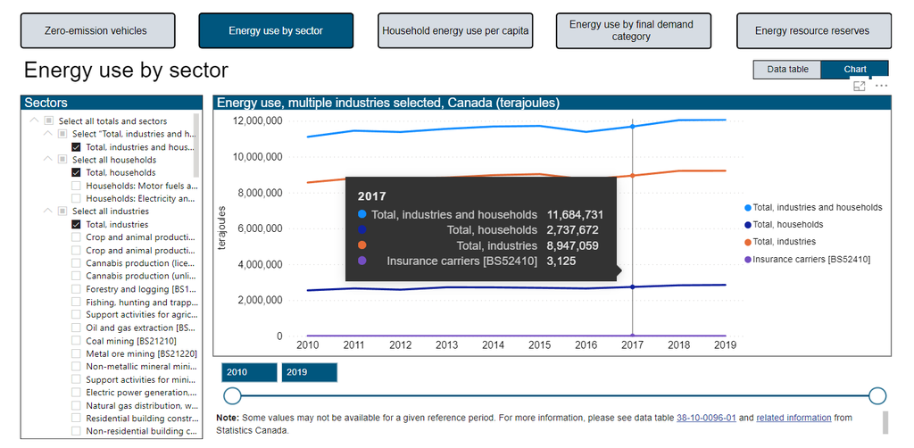

Image showing example usage of the interactive chart, credits to the CCEI

This update is part of the CCEI’s initiative to continuously improve the accessibility of energy related data within Canada.Check it out [here](https://energy-information.canada.ca/en/subjects/energy-and-environment).

## Rising food prices

#### [Yousaff Habib](https://www.linkedin.com/in/yousaff-habib-6684891a5/)

A report from the [IEA](https://www.iea.org/commentaries/how-the-energy-crisis-is-exacerbating-the-food-crisis) this week explains how the global energy crisis is a major factor in the rising price of food.

Russia’s invasion of Ukraine is one of the major causes of said energy crisis, driving up the costs of energy and having spillover effects on food supply chains primarily through three channels: disruption of food exports, increasing natural gas prices, and increased fertilizer prices.

The disruption and subsequent reduction of food exports from some of the [biggest global producers of wheat](https://worldpopulationreview.com/country-rankings/wheat-production-by-country) is a direct driver of rising food prices. Other factors are more subtle, but have equally profound effects.

Fertilizer is a major input cost ([roughly 15%](https://www.fb.org/market-intel/too-many-to-count-factors-driving-fertilizer-prices-higher-and-higher)) in the production of food. Natural gas accounts for 70%-80% of the cost of production of ammonia, the major precursor to nitrogen and urea fertilizers. As such, rising prices of energy in tandem with trade restrictions have nearly tripled fertilizer prices.

Furthermore, increased energy prices increase transportation costs which are in turn reflected in consumer prices.

Ultimately, these three factors in combination have lead to increasing food prices, a key driver of [inflation](https://www.statcan.gc.ca/en/subjects-start/prices_and_price_indexes/consumer_price_indexes) in Canada.

For further reading on the topic, see the [article](https://www.iea.org/commentaries/how-the-energy-crisis-is-exacerbating-the-food-crisis)

# Oil

## Weekly Crude Prices

### Feature Crude

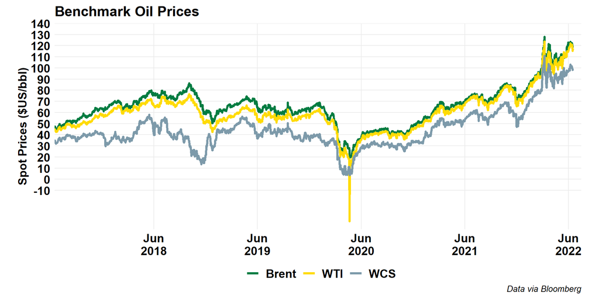

### Alberta Crude

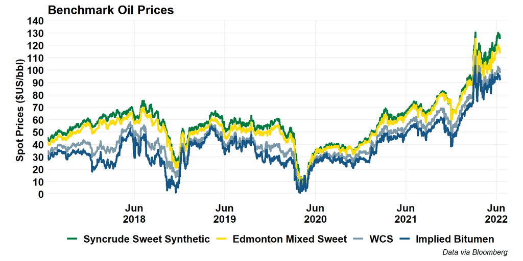

### US Crude

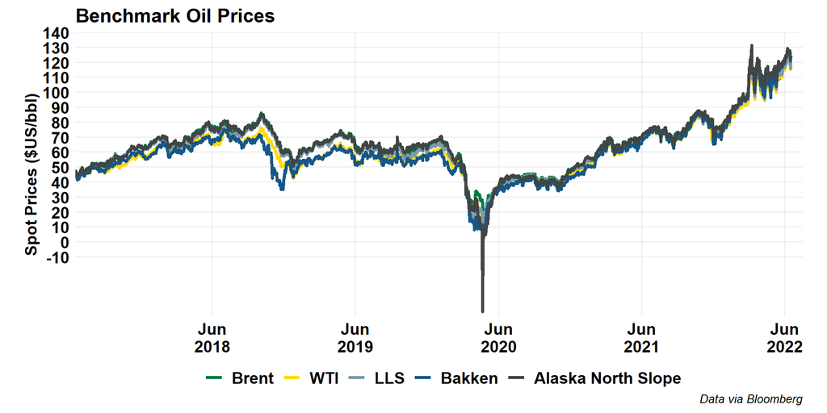

### Global Crude

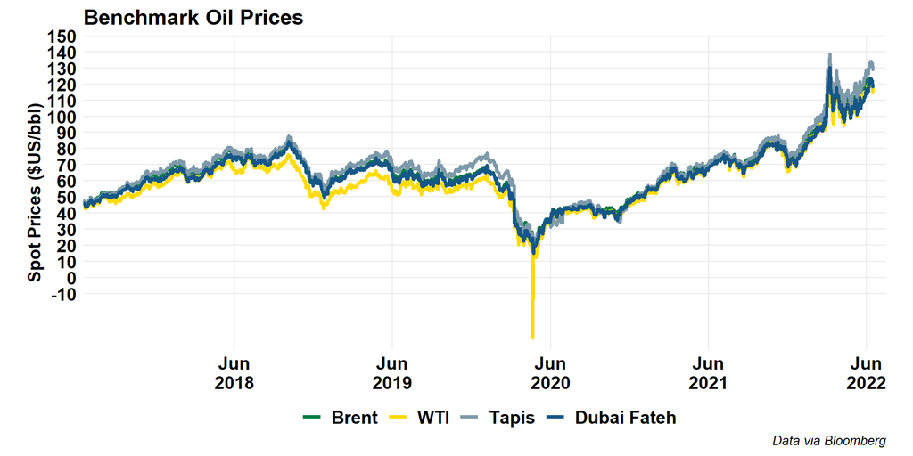

## Oil Price Differentials

### Brent-WTI

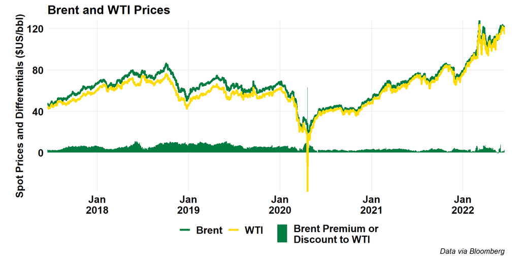

### WTI-WCS

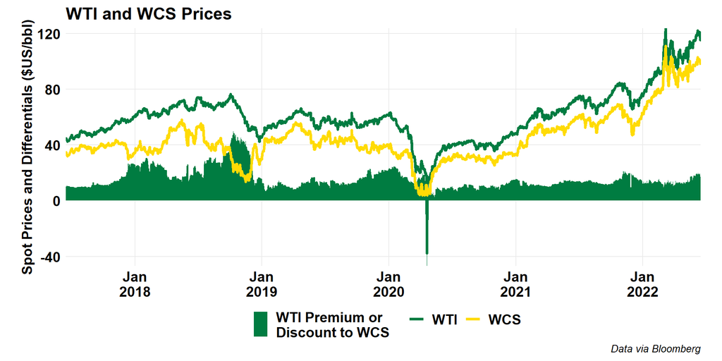

### Maya-WCS

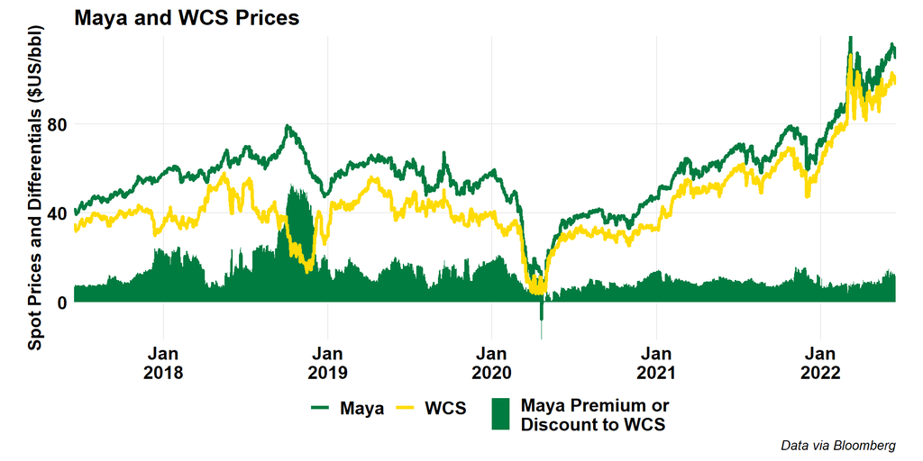

### WTI Cushing vs MEH

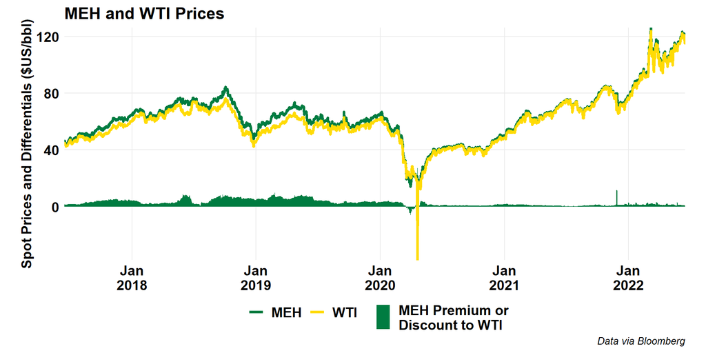

## Forward Curves

### WTI

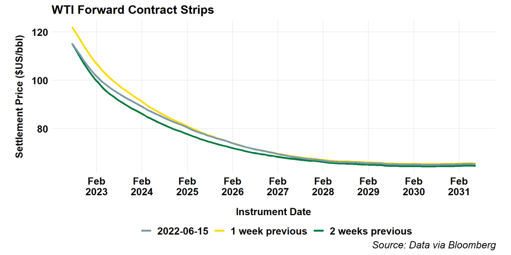

### Brent

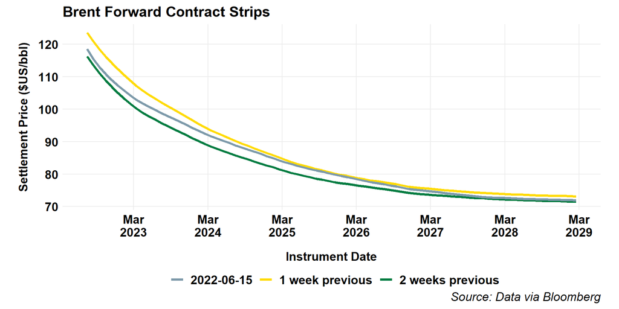

## Canadian Crude Supply and Disposition

### Production

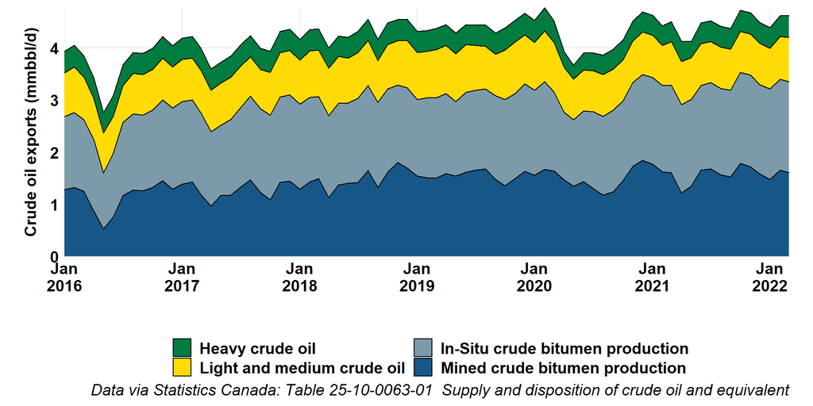

### Imports

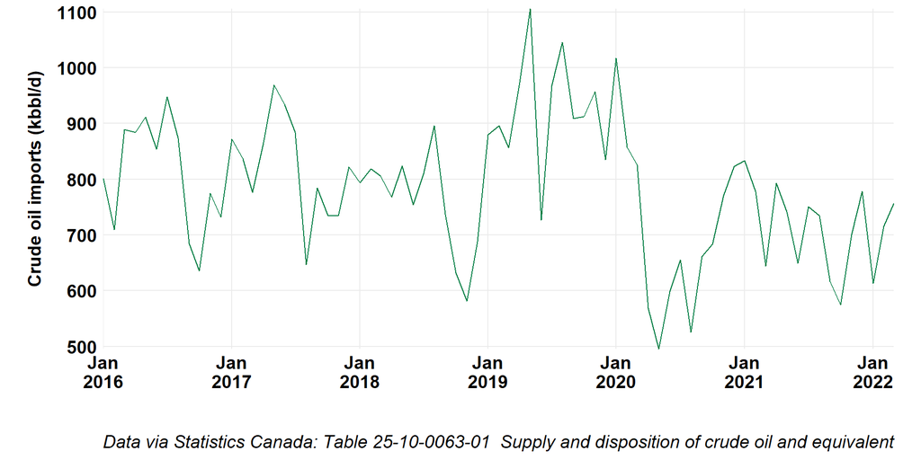

### Exports

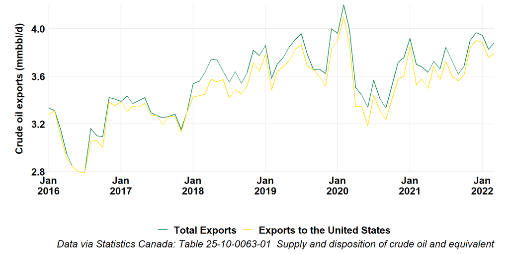

### Rail Exports

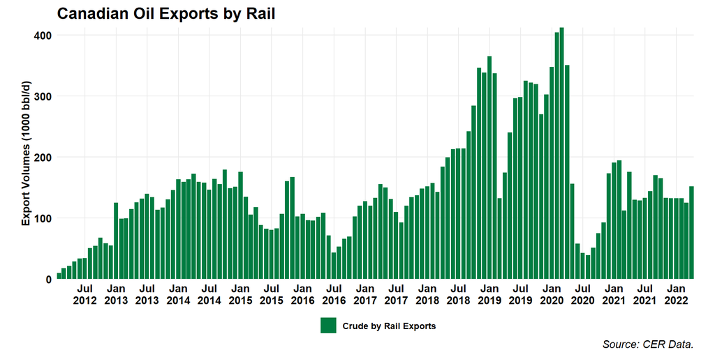

## US Oil

### Production

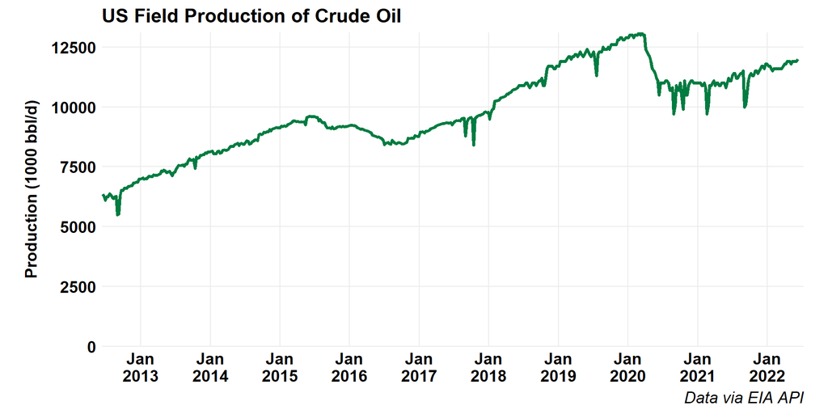

### LTO Production by Play

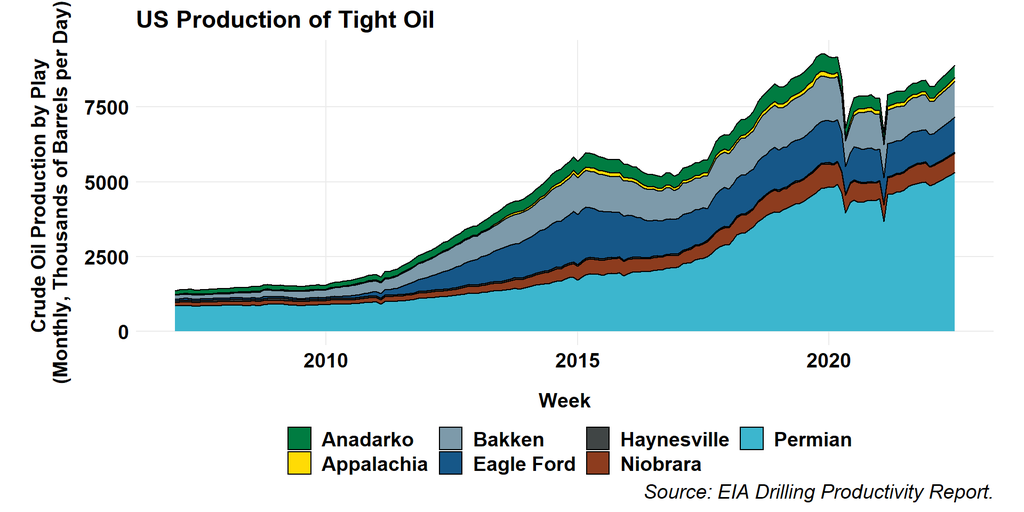

### Net Imports

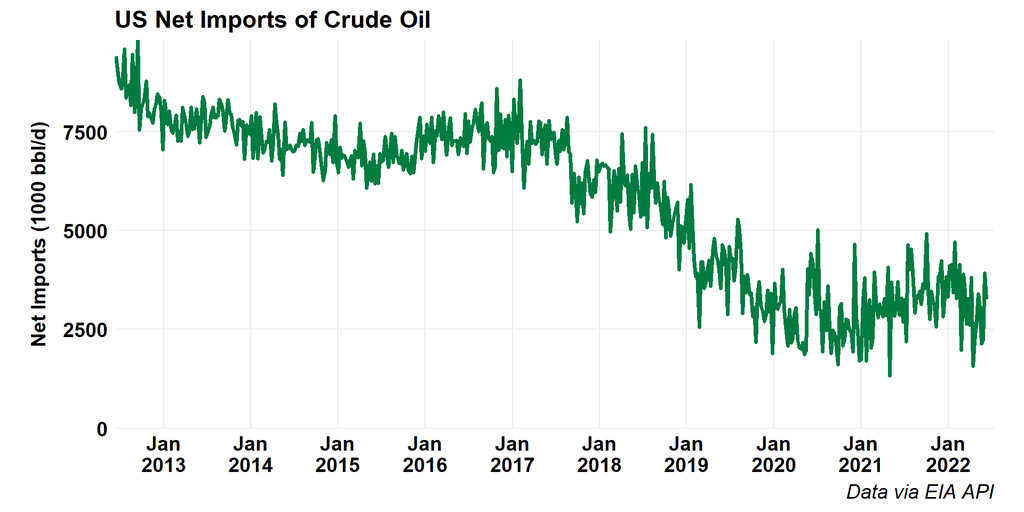

### Oil and Product Net Imports

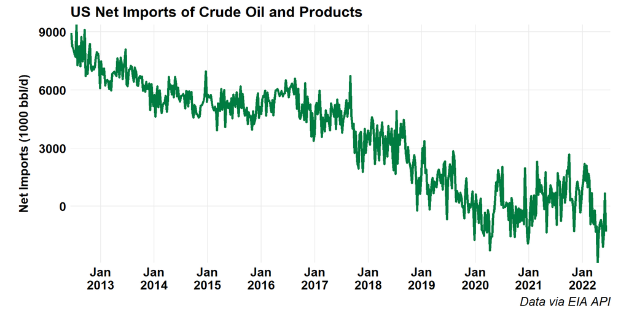

### Inventories

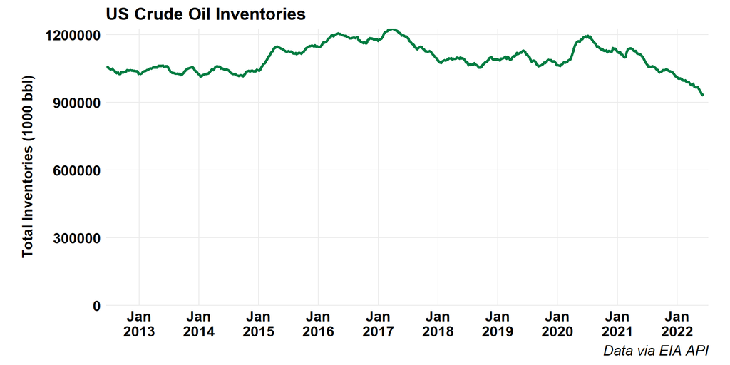

# Refined Products

## Canadian Gasoline Prices

### Map

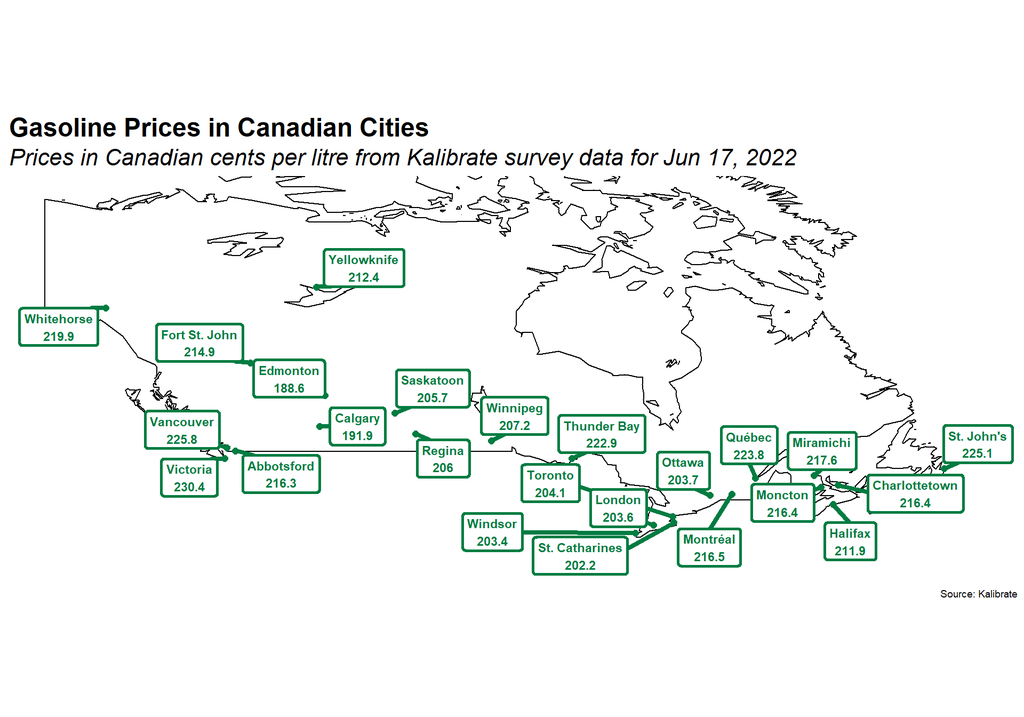

### Historic Gasoline Prices

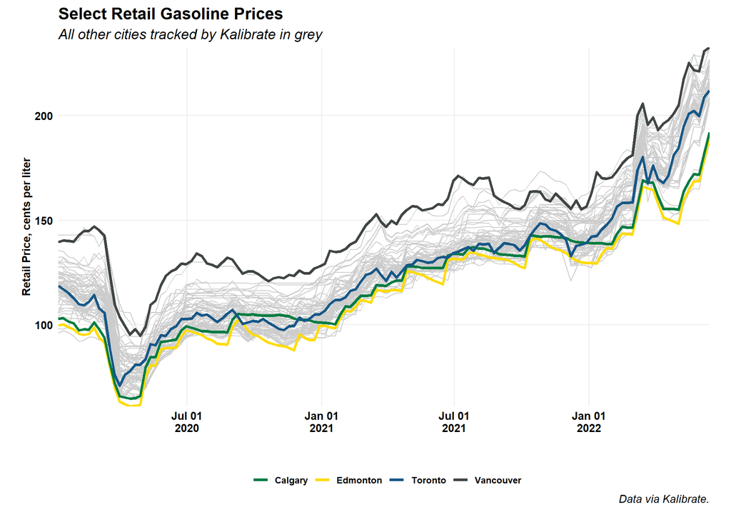

### Historic Diesel Prices

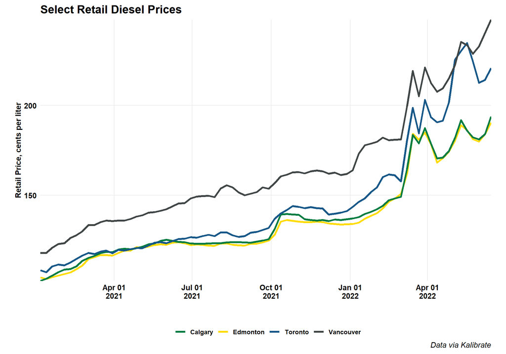

## Canadian Refinery Runs

### Canadian Refinery Runs

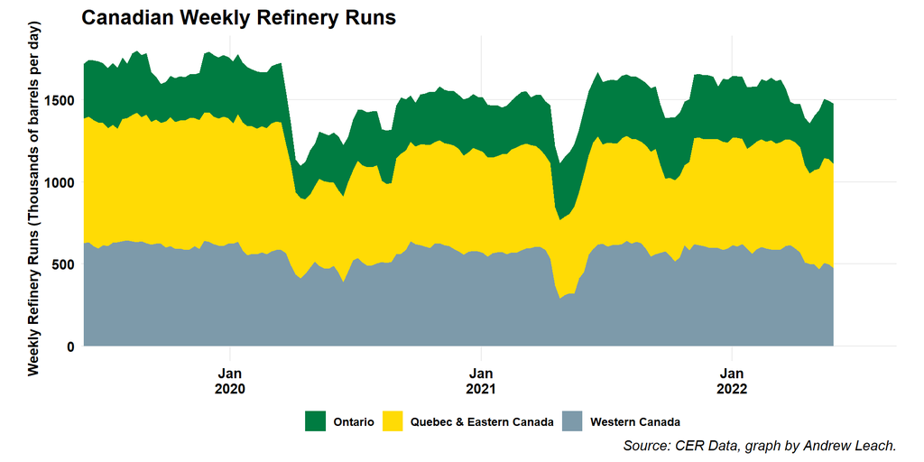

### Western Canada Refinery Runs

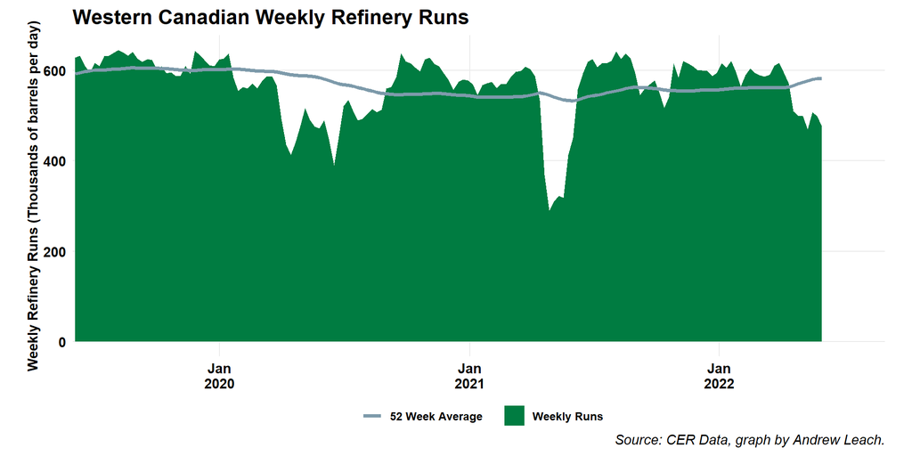

# Natural Gas

## Natural Gas Market Summary

### Feature Gas

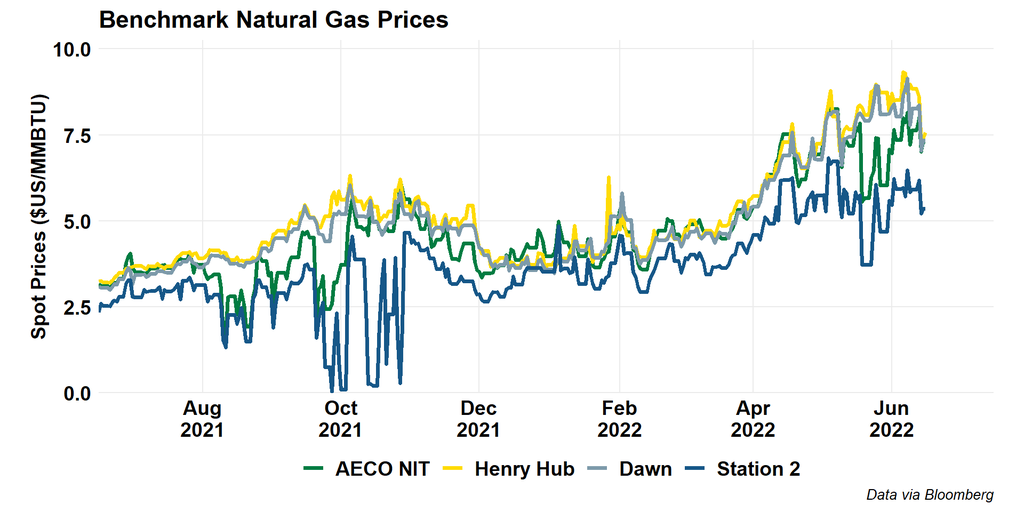

### Global Gas

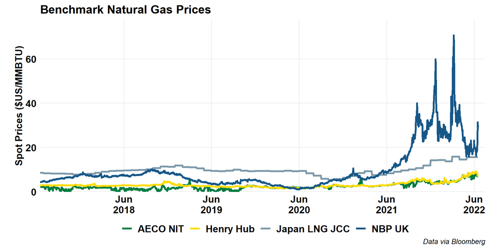

### North American Gas Hubs

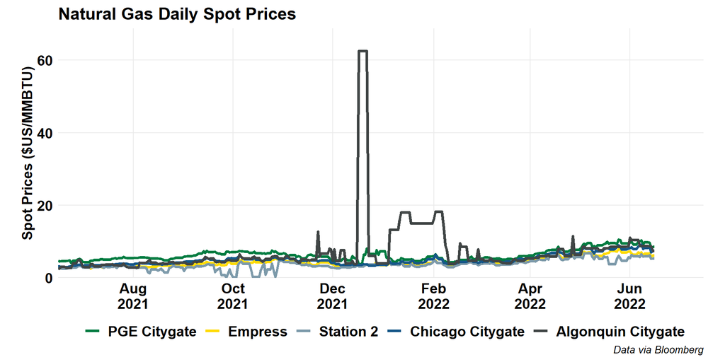

## Forward Prices

### Henry Hub

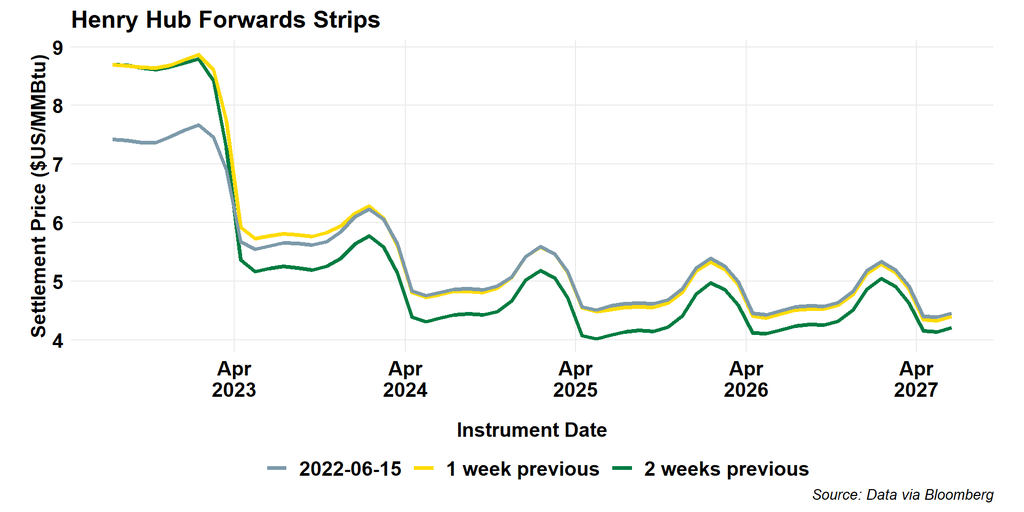

### Alberta (NIT) ($CAD)

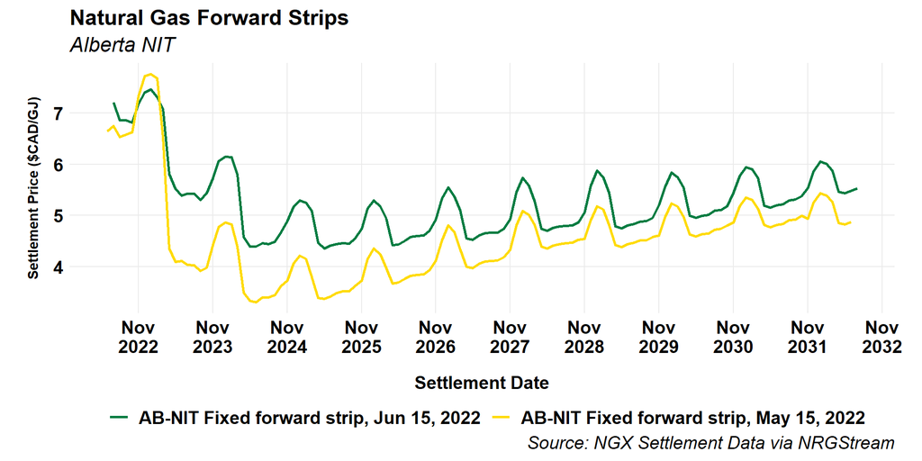

### Alberta (NIT)

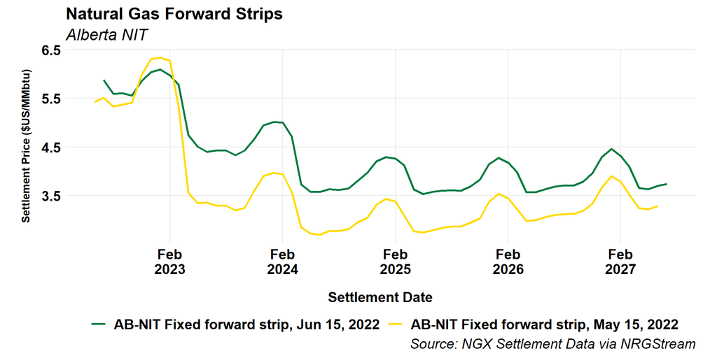